# NBACK AND LURES - Statistical Analysis

Deniz Guen

Thursday, September 24 09:00 CET

# Required R packages

- `tidyverse` (or `ggplot2`, `dplyr`, `purrr`, `tibble`)
- `brms`

### Setting seed for pseudo random operations

```r
set.seed(100) # this ensures that any psuedo-random computations are always the same
```

# Description

This file is a documentation of the statistical procedures that were used to analyse the data from the nback experiment that was deployed for the report ‘The Importance of controlling for lure foils in nback tasks’ by Deniz M. Gün

### Background: nback task

In the nback task participants are shown a sequence of stimuli. For every stimulus the participants have to indicate wether the same stimulus has been presented exactly n steps earlier. There are different variants that may require participants to pay attention to more than one modality at the same time (e.g. shape and color or number and sound). But for this experiment a simple variant was chosen.

The participants absolved 3- and 4back tasks with 100 trials for each, where the stimuli were integers between 1 and 9. They had 4 seconds to respond for each stimulus.

There were two groups that differed in the ratio of lure foils to other stimuli. In the control group the lure foils were just as likely as any other number (1/9) while in the main groups the lure foils were assigned with a probability of 1/4 each. The control group is supposed to demonstrate that the lower accuracy for lure foils is not a result of some unknown effect that simply arises from having more lure foils.

### Purpose

The n-back task is sometimes used in comparative studies to assess, e.g. wether a training programm had an effect on performances in working memory related tasks like the nback task. The performances of participants, however, may depend on the proportion of lure foils in the sequence of stimuli. So, this experiment is supposed to demonstrate that different kinds of stimuli which are usually not explicitly marked by experimentors significantly influence the results. Therefore in future experiments other researchers need to compare the performances on specific stimulus types to rule out their influence on their results.

# 1. Overview

#### Importing data

```r
data.raw = data.frame(read.csv("fake_data.csv"))
head(data.raw)
```

```
##   X submission_id      ID     QUD   RT     age comments correctness
## 1 1             1 Example Example 3728 Example  Example     correct
## 2 2             1 Example Example 1619 Example  Example     correct
## 3 3             1 Example Example 1025 Example  Example     correct
## 4 4             1 Example Example 1923 Example  Example     correct
## 5 5             1 Example Example 2450 Example  Example     correct
## 6 6             1 Example Example  826 Example  Example     correct
##         d education endTime expected experiment_id  gender    key1    key2
## 1 Example   Example Example  Example       Example Example Example Example
## 2 Example   Example Example  Example       Example Example Example Example
## 3 Example   Example Example  Example       Example Example Example Example
## 4 Example   Example Example  Example       Example Example Example Example
## 5 Example   Example Example  Example       Example Example Example Example
## 6 Example   Example Example  Example       Example Example Example Example
##   key_pressed languages       m n   pbait picture ptarget question
## 1     Example   Example Example 1 Example Example Example  Example
## 2     Example   Example Example 1 Example Example Example  Example
## 3     Example   Example Example 1 Example Example Example  Example
## 4     Example   Example Example 1 Example Example Example  Example
## 5     Example   Example Example 1 Example Example Example  Example
## 6     Example   Example Example 1 Example Example Example  Example
##   startDate startTime stim_type timeSpent trial_name trial_number
## 1   Example   Example  lure-n-1   Example   practice            1
## 2   Example   Example  lure-n-1   Example   practice            2
## 3   Example   Example  lure-n-1   Example   practice            3
## 4   Example   Example  lure-n-1   Example   practice            4
## 5   Example   Example  lure-n-1   Example   practice            5
## 6   Example   Example  lure-n-1   Example   practice            6
```

# 2. Data Cleaning

#### Removing non-pertinent data (practice sessions)

```r
data_pertinent = subset(data.raw, trial_name != "practice" & trial_number > n)
```

#### Removing irrelevant columns

The only relevant columns for now are the stimulus type, the correctness, the reaction time, trial name, n-condition, the trial number and the submission id (subject)

```r
data = subset(data_pertinent, select= c(stim_type,correctness,RT,trial_name,n,trial_number,submission_id))
```

#### Removing obviously Faulty Trials

Subjects with less than 200 trials overall:

```r
grouped = count(group_by(data, submission_id))
ids_faulty = filter(grouped, n < 200)$submission_id
data = subset(data, !(submission_id %in% ids_faulty))
```

#### Removing outliers with respect to Reaction Times (applying Rosner Test)

Should there be outliers, all entries for a specific submission ID will be removed

```r
normalize = function(data) {
  mu = mean(data)
  sig = sd(data)
  normalized = abs(data - mu)/sig
  return(normalized)
}

rosner_outlier_removal = function(data, var.col, crit.value){

  data$normalized = normalize(var.col)
  maximum = c( max(data$normalized), min(data$normalized) ) %>% abs() %>% max()

  if(maximum >= crit.value){
    data <- subset(data, abs(data$normalized) != maximum)
    return(rosner_test(data, data$normalized, crit.value))

  } else {
    return(data)
  }
}

get_outliers = function(data, var.col,grouping.variables, crit.value){
  #woo : "without outliers"
  data.woo = rosner_outlier_removal(data=data, var.col=var.col, crit.value=crit.value)
  data.woo = select(data.woo, c(1:(length(names(data.woo)))))

  all = select(data, grouping.variables)
  non_outliers = select(data.woo, grouping.variables)
  outliers = anti_join(all,non_outliers)
  return(outliers)
}
```

We find the outliers based on unlikely reaction times using the rosner test for outlier detection ( and removal).

#### Adding column stim_type_gross

Could be interesting for plotting.

```r
gross = data$stim_type
gross = ifelse(data$stim_type == "target", "target", "non-target")
data$gross_stimtype = gross
```

#### Creating a table with accuracy for different IDs and stimuli

The grouping is important for counting the stimuli for a specific combination of values (e.g.: ID = 1, stim_type = “non-target”, correctness = “correct”, n=3, etc..) such that the acuracy for a specific kind of stimulus can be calculated.

```r
#Grouping by ID stim type, trial name and n --- 'nn' is the total number of trials for the specific variable combination of each row
grouped1 = data %>% group_by(submission_id,stim_type,gross_stimtype,trial_name,n)
cg1 = count(grouped1)
#Grouping by correctness for counts of "correct" or "incorrect" --- 'nn' is number of correct trials for the specific variable combination of each row
grouped2 = grouped1 %>% group_by(correctness, add=TRUE)
cg2 = count(grouped2)
# Getting list with unique values to iterate through in the following cells
IDs = unique(grouped1$submission_id)
stim_types = unique(grouped1$stim_type)
gross_stimtypes = unique(grouped1$gross_stimtype)
trial_names = c("main", "control")
N = c("3", "4")
```

##### Creating an accuracy table template

```r
# Accuracy table must be a table with the following rows: ID, trial_name, n, stimulus_type, gross_stimulus_type and accuracy
accuracy_table <- data.frame(matrix(ncol = 6, nrow = 0))
colnames(accuracy_table) <- c("ID","trial_name", "stimulus_type","gross_stimulus_type","n", "accuracy")

# Defining the right variable types for cols.
accuracy_table$submission_id <- as.factor(accuracy_table$submission_id)
accuracy_table$accuracy <- as.numeric(accuracy_table$accuracy)
accuracy_table$n <- as.factor(accuracy_table$n)
```

###### Fill a complete accuracy table ordered on all relevant variables.

```r
accu_complete <- subset(accuracy_table, select=c(ID, trial_name, stimulus_type, gross_stimulus_type, n, accuracy))

for(id in IDs){
  for(n in N){
    for(st in stim_types){

      howmanyback = n
      trial_name = filter(data,submission_id==id)$trial_name[1]
      gr_st = filter(data, stim_type == st)$gross_stimtype[1]
      n_correct = sum( filter(cg2, (submission_id == id && stim_type == st) && (n == howmanyback && correctness == "correct"))$nn )
      n_total = sum( filter(cg2, (submission_id == id && n == howmanyback) && stim_type == st)$nn )
      accuracy = n_correct/n_total

      entry = data.frame(submission_id = id, trial_name = trial_name, stimulus_type = st, gross_stimulus_type = gr_st, n = howmanyback, accuracy = accuracy, count = n_total)
      accu_complete <- rbind(accu_complete, entry)
    }
  }
}
head(accu_complete)
```

```
##   submission_id trial_name stimulus_type gross_stimulus_type n  accuracy
## 1             1    control    non-target          non-target 3 0.9433962
## 2             1    control        target              target 3 0.7777778
## 3             1    control      lure-n-1          non-target 3 0.8235294
## 4             1    control      lure-n+1          non-target 3 0.7500000
## 5             1    control    non-target          non-target 4 0.9411765
## 6             1    control        target              target 4 0.7368421
##   count
## 1    53
## 2    18
## 3    17
## 4    12
## 5    51
## 6    19
```

##### Variables

Dependent: Accuracy Independent: trial_name, (gross_)stimulus_type, id, n, count

```r
accu_complete$submission_id <- as.factor(accu_complete$submission_id)
accu_complete$n <- as.factor(accu_complete$n)
```

# 3. Hypothesis Tests

#### The proposed hypotheses were

$H1_a$ and $H1_b$: The accuracy for lure foils at n-1 ($a$) as well as at n+1($b$)) is lower than the accuracy of non-targets.

$H0_c$: The accuracy of lure foils at n+1 does not differ significantly from lure foils at n-1.

###### Getting an Overview

First we get an overview to illustrate the data

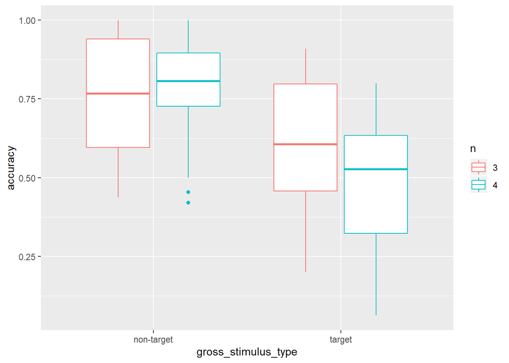

```r
ggplot(accu_complete,mapping=aes(x=gross_stimulus_type, y=accuracy, color=n))+
  geom_boxplot()
```

### Model

```r
names(accu_complete)
```

```
## [1] "submission_id"       "trial_name"          "stimulus_type"
## [4] "gross_stimulus_type" "n"                   "accuracy"
## [7] "count"
```

We’ll make accuracy in our formula dependend on the fixed effects stimulus_type and n and include the random intercepts for subjects (=“submission_id”) and groups (=“trial_name”)

```r
formula = bf(accuracy ~ stimulus_type*n+(1|submission_id)+(1|trial_name),
          sigma ~ stimulus_type*n+(1|submission_id) + (1|trial_name))
```

Now we create a bayesian regression model where we assume student’s distribution (Kruschker’s Model: Robust Bayesian Estimation)

```r
accu_complete.mdl.brm = brm(formula, data=accu_complete, family="student")
```

# Testing Hypotheses

In order to test our hypotheses we look at the coefficients from our posterior samples, which we obtained from the model above using MCMC.

If a coefficient, say e.g. “b_stimulus_typetarget” of one sample is smaller than 0, this indicates the following: Based on our estimates for the real parameters, there is a sample drawn from our posterior distribution for which it is true, that the mean accuracy for the stimulus type “target” is lower than the mean accuracy for the stimulus type “non-target” which is our intercept.

What we are going to do in order to assess the probabilities of our hypotheses, is, look at the ratio of samples for which a coefficient like e.g. “b_stimulus_typetarget” is smaller than 0.

We predict that the accuracy is lower for all kinds of lures than it is for non-targets. We’ll accept in a preliminary fashion that our hypotheses is true if the probability that one of the mentioned coefficients is lower than the intercept is at least 95%.

```r
accu_complete.mdl.brm
```

```
##  Family: student
##   Links: mu = identity; sigma = log; nu = identity
## Formula: accuracy ~ stimulus_type * n + (1 | submission_id) + (1 | trial_name)
##          sigma ~ stimulus_type * n + (1 | submission_id) + (1 | trial_name)
##    Data: accu_complete (Number of observations: 64)
## Samples: 4 chains, each with iter = 2000; warmup = 1000; thin = 1;
##          total post-warmup samples = 4000
##
## Group-Level Effects:
## ~submission_id (Number of levels: 8)
##                     Estimate Est.Error l-95% CI u-95% CI Eff.Sample Rhat
## sd(Intercept)           0.08      0.03     0.04     0.15        104 1.01
## sd(sigma_Intercept)     0.34      0.24     0.03     0.92         48 1.09
##
## ~trial_name (Number of levels: 1)
##                     Estimate Est.Error l-95% CI u-95% CI Eff.Sample Rhat
## sd(Intercept)           6.52      5.76     0.43    22.10         44 1.09
## sd(sigma_Intercept)     5.65      7.02     0.15    23.59         57 1.08
##
## Population-Level Effects:
##                                Estimate Est.Error l-95% CI u-95% CI
## Intercept                          0.47      4.90   -11.74     9.43
## sigma_Intercept                   -2.19      4.84   -11.47     8.23
## stimulus_typetarget               -0.33      0.09    -0.50    -0.16
## stimulus_typelureMnM1             -0.28      0.07    -0.41    -0.14
## stimulus_typelureMnP1             -0.26      0.05    -0.37    -0.18
## n4                                -0.05      0.03    -0.11     0.02
## stimulus_typetarget:n4            -0.02      0.12    -0.26     0.20
## stimulus_typelureMnM1:n4           0.00      0.13    -0.24     0.29
## stimulus_typelureMnP1:n4           0.17      0.07     0.06     0.32
## sigma_stimulus_typetarget          1.17      0.52     0.27     2.18
## sigma_stimulus_typelureMnM1        0.80      0.60    -0.27     2.05
## sigma_stimulus_typelureMnP1        0.38      0.59    -0.69     1.58
## sigma_n4                          -0.80      1.22    -3.34     1.01
## sigma_stimulus_typetarget:n4       0.68      1.26    -1.24     3.37
## sigma_stimulus_typelureMnM1:n4     1.05      1.39    -1.37     3.76
## sigma_stimulus_typelureMnP1:n4     0.82      1.21    -1.20     3.25
##                                Eff.Sample Rhat
## Intercept                              25 1.17
## sigma_Intercept                       121 1.04
## stimulus_typetarget                    58 1.08
## stimulus_typelureMnM1                  52 1.07
## stimulus_typelureMnP1                  75 1.05
## n4                                     75 1.05
## stimulus_typetarget:n4                 98 1.03
## stimulus_typelureMnM1:n4               52 1.10
## stimulus_typelureMnP1:n4               80 1.03
## sigma_stimulus_typetarget               9 1.23
## sigma_stimulus_typelureMnM1            10 1.21
## sigma_stimulus_typelureMnP1            27 1.13
## sigma_n4                                3 1.88
## sigma_stimulus_typetarget:n4            3 1.78
## sigma_stimulus_typelureMnM1:n4          3 1.70
## sigma_stimulus_typelureMnP1:n4          3 1.69
##
## Family Specific Parameters:
##    Estimate Est.Error l-95% CI u-95% CI Eff.Sample Rhat
## nu    22.45     13.92     5.54    59.00        169 1.00
##
## Samples were drawn using sampling(NUTS). For each parameter, Eff.Sample
## is a crude measure of effective sample size, and Rhat is the potential
## scale reduction factor on split chains (at convergence, Rhat = 1).
```

$H1:$ *Lure foils are less probable than non-targets.*

```r
post.samples = posterior_samples(accu_complete.mdl.brm)
#For n3
p.H1a = mean(post.samples$b_stimulus_typelureMnM1 < post.samples$b_stimulus_typenonMtarget)
p.H1b = mean(post.samples$b_stimulus_typelureMnP1 < post.samples$b_stimulus_typenonMtarget)

p.hypotheses = data.frame(H1a = p.H1a, H1b = p.H1b)

#For the interaction with n4
p.H1a.n4 = mean(post.samples$b_stimulus_typelureMnM1 +
               post.samples$"b_stimulus_typelureMnM1:n4" +
               post.samples$"b_n4" < post.samples$b_stimulus_typenonMtarget)

p.H1b.n4 = mean(post.samples$b_stimulus_typelureMnP1 +
               post.samples$"b_stimulus_typelureMnP1:n4" +
               post.samples$"b_n4" < post.samples$b_stimulus_typenonMtarget)

p.hypotheses = rbind(p.hypotheses, data.frame(H1a = p.H1a.n4, H1b = p.H1b.n4))
p.hypotheses$n <- as.factor(c(3,4))

print(p.hypotheses)
```

```
##   H1a H1b n
## 1 NaN NaN 3
## 2 NaN NaN 4
```

Now, we can’t show that the accuracies for lures at n-1 and n+1 are ‘significantly similar’. What we can try to show, at least, is that one is not significantly higher than the other. It is to be kept in mind, however, that this is not an appropriate procedure to conduct hypotheses testing but merely provides an intimation of the relationship between the two kinds of lures. The results will be stored in the column “H1c” below.

```r
# Testing wether lures at n+1 are significantly more accurate than lures at n-1
p.H1c = mean(post.samples$b_stimulus_typelureMnP1 > post.samples$b_stimulus_typelureMnM1)
#Considering the interaction with and the intercept for n=4
p.H1c.n4 = mean(post.samples$b_stimulus_typelureMnP1 +
                  post.samples$"b_stimulus_typelureMnP1:n4"
                > post.samples$b_stimulus_typelureMnM1 +
                  post.samples$"b_stimulus_typelureMnM1:n4")

p.hypotheses <- add_column(p.hypotheses, c(p.H1c, p.H1c.n4), .before="n")
colnames(p.hypotheses)[3] <- "H1c"
print(p.hypotheses)
```

```
##   H1a H1b     H1c n
## 1 NaN NaN 0.55525 3
## 2 NaN NaN 0.95625 4
```

# Code Summary

```r
library(tidyverse)
library(rstan)
library(brms)
library(lme4)
options(mc.cores = max(parallel::detectCores()-1, 1)) # at least one core if the machine only has one
rstan_options(auto_write = TRUE)
set.seed(100)

data.raw = data.frame(read.csv("fake_data.csv"))
data_pertinent = subset(data.raw, trial_name != "practice" & trial_number > n)
data = subset(data_pertinent, select= c(stim_type,correctness,RT,trial_name,n,trial_number,submission_id))

# Removing obviously Faulty Trials
grouped = count(group_by(data, submission_id))
ids_faulty = filter(grouped, n < 200)$submission_id
data = subset(data, !(submission_id %in% ids_faulty))

#Defining Functions for outlier detection and removal
#####################################################################################
normalize = function(data) {
  mu = mean(data)
  sig = sd(data)
  normalized = abs(data - mu)/sig
  return(normalized)
}

rosner_outlier_removal = function(data, var.col, crit.value){

  data$normalized = normalize(var.col)
  maximum = c( max(data$normalized), min(data$normalized) ) %>% abs() %>% max()

  if(maximum >= crit.value){
    data <- subset(data, abs(data$normalized) != maximum)
    return(rosner_test(data, data$normalized, crit.value))

  } else {
    return(data)
  }
}

get_outliers = function(data, var.col,grouping.variables, crit.value){
  #woo : "without outliers"
  data.woo = rosner_outlier_removal(data=data, var.col=var.col, crit.value=crit.value)
  data.woo = select(data.woo, c(1:(length(names(data.woo)))))

  all = select(data, grouping.variables)
  non_outliers = select(data.woo, grouping.variables)
  outliers = anti_join(all,non_outliers)
  return(outliers)
}
##############################################################################################################################
mean_rts = aggregate(data$RT, FUN=mean, by=list(data$submission_id, data$n))
names(mean_rts) = c("submission_id", "n", "x")

outliers = get_outliers(data=mean_rts, var.col=mean_rts$x,
                         grouping.variables=c("submission_id", "n"), crit.value=3)
if(nrow(outliers)>0){
  for(row in c(1:nrow(outliers))){
    sprintf("ID: %d, n: %d",outliers$submission_id[row], outliers$n[row] )
    data <- subset(data, submission_id != outliers$submission_id[row] , n != outliers$n[row])
  }
}

# Adding column stim_type_gross
gross = data$stim_type
gross = ifelse(data$stim_type == "target", "target", "non-target")
data$gross_stimtype = gross

#Grouping by ID stim type, trial name and n --- 'nn' is the total number of trials for the specific variable combination of each row
grouped1 = data %>% group_by(submission_id,stim_type,gross_stimtype,trial_name,n)
cg1 = count(grouped1)
#Grouping by correctness for counts of "correct" or "incorrect" --- 'nn' is number of correct trials for the specific variable combination of each row
grouped2 = grouped1 %>% group_by(correctness, add=TRUE)
cg2 = count(grouped2)
# Getting list with unique values to iterate through in the following cells
IDs = unique(grouped1$submission_id)
stim_types = unique(grouped1$stim_type)
gross_stimtypes = unique(grouped1$gross_stimtype)
trial_names = c("main", "control")
N = c("3", "4")

# Accuracy table must be a table with the following rows: ID, trial_name, n, stimulus_type, gross_stimulus_type and accuracy
accuracy_table <- data.frame(matrix(ncol = 6, nrow = 0))
colnames(accuracy_table) <- c("ID","trial_name", "stimulus_type","gross_stimulus_type","n", "accuracy")

# Defining the right variable types for cols.
accuracy_table$submission_id <- as.factor(accuracy_table$submission_id)
accuracy_table$accuracy <- as.numeric(accuracy_table$accuracy)
accuracy_table$n <- as.factor(accuracy_table$n)
accu_complete <- subset(accuracy_table, select=c(ID, trial_name, stimulus_type, gross_stimulus_type, n, accuracy))

for(id in IDs){
  for(n in N){
    for(st in stim_types){

      howmanyback = n
      trial_name = filter(data,submission_id==id)$trial_name[1]
      gr_st = filter(data, stim_type == st)$gross_stimtype[1]
      n_correct = sum( filter(cg2, (submission_id == id && stim_type == st) && (n == howmanyback && correctness == "correct"))$nn )
      n_total = sum( filter(cg2, (submission_id == id && n == howmanyback) && stim_type == st)$nn )
      accuracy = n_correct/n_total

      entry = data.frame(submission_id = id, trial_name = trial_name, stimulus_type = st, gross_stimulus_type = gr_st, n = howmanyback, accuracy = accuracy, count = n_total)
      accu_complete <- rbind(accu_complete, entry)
    }
  }
}
accu_complete$submission_id <- as.factor(accu_complete$submission_id)
accu_complete$n <- as.factor(accu_complete$n)

#Plotting Data
ggplot(accu_complete,mapping=aes(x=gross_stimulus_type, y=accuracy, color=n))+
  geom_boxplot()

accu_complete <- rosner_outlier_removal(accu_complete, var.col=accu_complete$accuracy, crit.value=3)
ggplot(data=accu_complete, mapping=aes(x=stimulus_type, y=accuracy, color=n))+
  geom_boxplot()
names(accu_complete)

# Creating the Model
formula = bf(accuracy ~ stimulus_type*n+(1|submission_id)+(1|trial_name),
          sigma ~ stimulus_type*n+(1|submission_id) + (1|trial_name))
accu_complete.mdl.brm = brm(formula, data=accu_complete, family="student")
#Testing Hypotheses
post.samples = posterior_samples(accu_complete.mdl.brm)
p.H1a = mean(post.samples$b_stimulus_typelureMnM1 < post.samples$b_stimulus_typenonMtarget)
p.H1b = mean(post.samples$b_stimulus_typelureMnP1 < post.samples$b_stimulus_typenonMtarget)
p.hypotheses = data.frame(H1a = p.H1a, H1b = p.H1b)
# Interaction with n=4
p.H1a.n4 = mean(post.samples$b_stimulus_typelureMnM1 +
               post.samples$"b_stimulus_typelureMnM1:n4" +
               post.samples$"b_n4" < post.samples$b_stimulus_typenonMtarget)
p.H1b.n4 = mean(post.samples$b_stimulus_typelureMnP1 +
               post.samples$"b_stimulus_typelureMnP1:n4" +
               post.samples$"b_n4" < post.samples$b_stimulus_typenonMtarget)
p.hypotheses = rbind(p.hypotheses, data.frame(H1a = p.H1a.n4, H1b = p.H1b.n4))
p.hypotheses$n <- as.factor(c(3,4))
print(p.hypotheses)
p.H1c = mean(post.samples$b_stimulus_typelureMnP1 > post.samples$b_stimulus_typelureMnM1)
#Considering the interaction with and the intercept for n=4
p.H1c.n4 = mean(post.samples$b_stimulus_typelureMnP1 +
                  post.samples$"b_stimulus_typelureMnP1:n4"
                > post.samples$b_stimulus_typelureMnM1 +
                  post.samples$"b_stimulus_typelureMnM1:n4")

p.hypotheses <- add_column(p.hypotheses, c(p.H1c, p.H1c.n4), .before="n")
colnames(p.hypotheses)[3] <- "H1c"
print(p.hypotheses)
```